# Pillar 5: Capstone Project_30-Day Hospital Readmission Prediction

## Problem Background

> *"The Centers for Medicare & Medicaid Services (CMS) of the U.S. government pays hospital for Medicare patients (low-income government-insured patients). Thus, they established to define hospital quality metrics and directly ties their payment to the hospital performance."*

> *"One of their quality metrics is Hospital Readmission within 30 days which is a proxy for quality care and a sign of poor discharge planning, care coordination, or follow-up. Because of this, CMS treats avoidable readmissions as costly failures and penalizes hospitals by losing a percentage of total Medicare inpatient payments."* *"Since safety-net hospitals that serve sicker or older population would be unfairly punished, CMS risk-adjustment exists for age, sex, comorbidities, prior diagnoses, clinical severity, and past utilization."*

> *"Readmission reduction indirectly helps hospitals by keeping bonuses, avoid downstream losses, and improve insurer negotiations."*

### **Step 1: Problem Understanding & Framing**

> *"This project mirrors* *CMS risk-adjusted readmission modeling** used in U.S. hospital reimbursement, where inaccurate prediction can lead to multi-million-dollar penalties."*

#### Risk-adjusted Benchmarks Table:

| **Aspect** | **CMS Approach** |
| --- | --- |
| Metric | 30-day unplanned readmission |
| Model type | Risk-adjusted logistic regression |
| Adjustment factors | Age, comorbidities, clinical history |
| Financial impact | Up to ~3% Medicate payment reduction |
| Incentive structure | Penalty-focused |

### **Step 2: Data Collection & Understanding**

> *"The data set represents 10 years (1999-2008) of clinical care at 130 US hospitals and integrated delivery network."*

> *"It includes over 50 features representing patient and hospital outcomes where different situations could be possibly identified if it will result to <30-day readmission or not."*

#### **Dataset Summary:**

| Attribute | Description |
| --- | --- |
| Number of patients | ~100,000 hospital encounters |
| Number of features | 50 raw columns |
| Target variable | 30-day readmission status |
| Class Imbalance | Yes (~11% readmitted within 30 days) |

#### **Feature Categories:**

| Demographic Features | Admission & Discharge Information | Clinical & Diagnosis Features | Medication & Treatment Indicators | Utilization History |
| --- | --- | --- | --- | --- |
| `age` | `admission_type` | `num_lab_procedures` | `insulin` | `number_inpatient` |
| `gender` | `admission_source` | `num_medications` | `metformin` | `number_emergency` |
| `race` | `discharge_disposition` | `number_diagnoses` | `change` | `number_outpatient` |
| `payer_code` | `time_in_hospital` | `diag_1, diag_2, diag_3` | `diabetesMed` |  |

#### **Data Dictionary:**

| Variable Name | Type | Description | Allowed Values |
| --- | --- | --- | --- |
| `encounter_id` | integer | unique identifier for each hospital encounter ... | 12522-443867222 |
| `patient_nbr` | integer | unique identifier for each patient | 135-189502619 |
| `race` | object | patient's race | AfricanAmerican, Asian, .. |
| `gender` | object | patient's gender | Female, Male, Unknown |
| `age` | object | age group of the patient, reported in intervals | [0-10), [10-20), .. |

Source: UCI Machine Learning Repository. (n.d.). https://archive.ics.uci.edu/dataset/296/diabetes+130-us+hospitals+for+years+1999-2008

Fill Categorical Missing Values

#### **3. Exploratory Data Analysis (EDA)**

*In alignment with CMS-style readmission metrics, this EDA explored to understand the structure, quality, and clinical context of the dataset.*

**Demographic Features EDA Questions:** *To understand baseline population heterogeneity*

- What percentage of encounters result in 30-day readmission?
- Are there patients with multiple encounters contributing multiple rows?
- Are there differences by gender?
- How does readmission rate vary by age group?
- Are there differences by race/ethnicity?
- Do payer categories show different readmission rates?

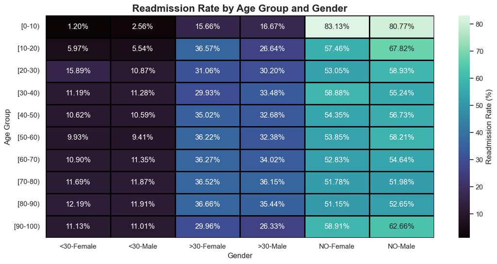

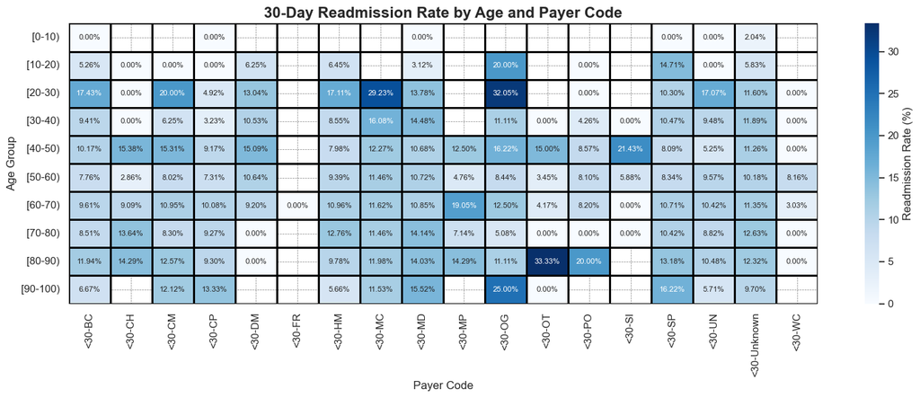

##### **Demographic Insights:**

**Total population**

- **23.45%** of the total number of patients have multiple encounters.

**Gender Comparison**

- Female and Male genders have almost the same <30-day hospital readmission rate (~11%)

**Age Comparison**

- Sudden increase in <30-day hospitalreadmission rate from ages 10-20 (5.79%) to ages 20-30 (14.24%).
- Gradual decrease in <30-day readmission rate from ages 20-30 (14.24%) to ages 50-60 (9.66%).
- Ages 60 and above plateau to a <30-day readmission rate of ~11% with slight increase to 12% in ages 80-90.

**Age & Gender Comparison**

**Age-Race Comparison**

**Payer Code**

- The top 5 highest <30-day hospital readmission rate by payer code (OG, SI, MD, MC, DM) are all under Government Insurance that represents the socioeconomically vulnerable populations like the elderly, the disabled and the low-income patients.

**Age & Payer Code Comparison**

**Admission and Discharge Features EDA Questions:**

*To evaluate care pathways among readmitted cases without assuming causality*

- How does readmission vary by admission type (emergency vs elective)?
- Does admission source affect readmission?
- How does discharge disposition relate to readmission?

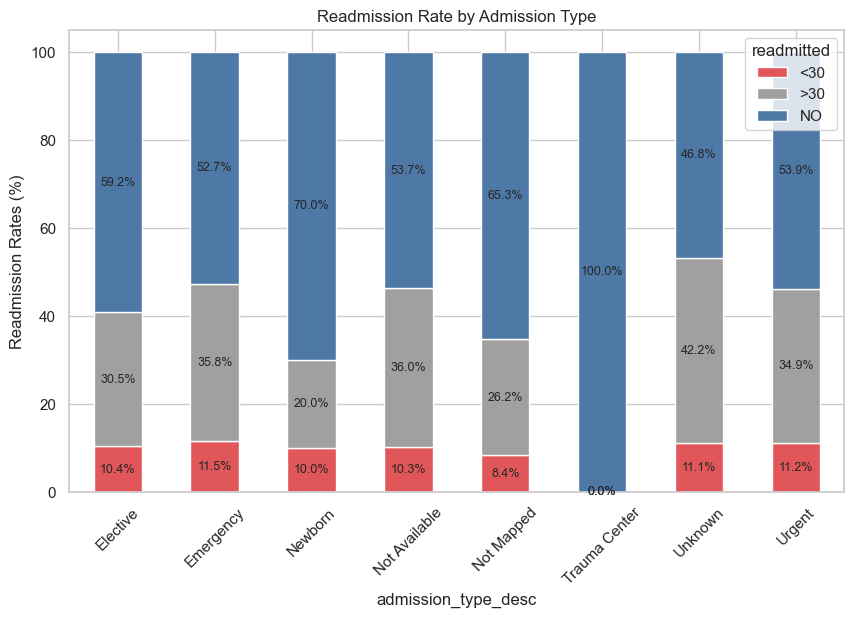

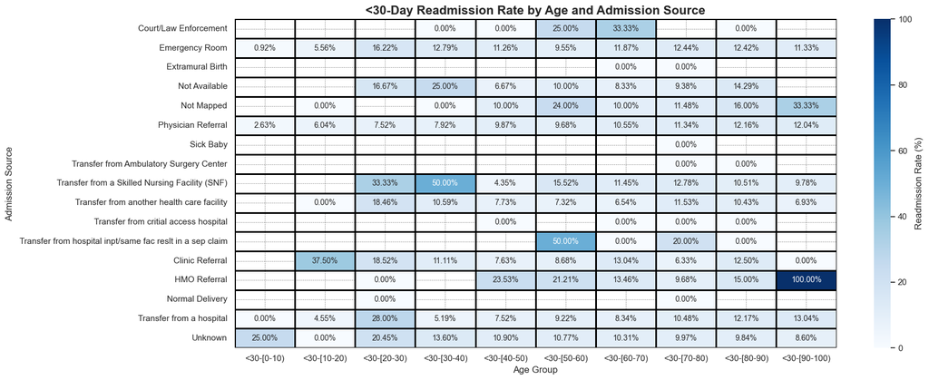

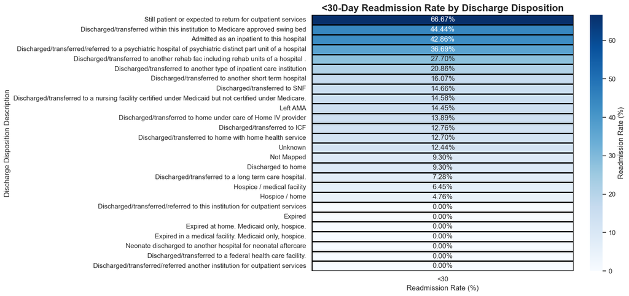

##### **Admission and Discharge Insights**

**Admission Type**

- Highest <30-day hospital readmission rate for **Emergency** patients with 11.5% closely followed by **Urgent** patients with 11.2%
- **Elective** admissions is at 10.4% readmission rate which I think is considered still close to **Emergency** rate.
- This indicates that planned procedures does not generally mean low admission risk. Severity must still be a major factor.

**Admission Source**

- Highest <30-day hospital readmission rate for **Transfer from hospital inpt/facility** patients with 16.67% closely followed by **HMO Referral** patients with 15.51%

**Discharge Disposition**

- Highest <30-day hospital readmission rate for **Still patient or expected to return for outpatient services** with 66.67%

**Utilization & Severity Features EDA Questions:**

*To assess operational and healthcare in the year prior to admission*

- How does length of stay relate with readmission?
- How does prior utilization relate with readmission?

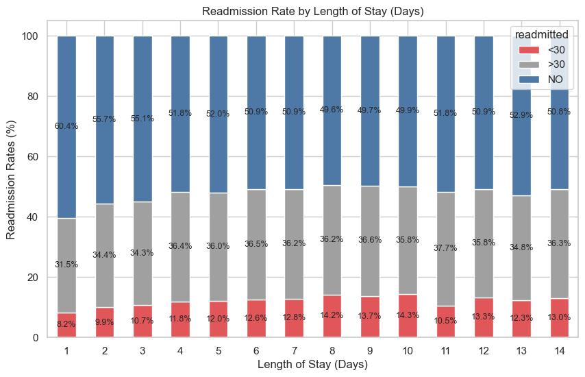

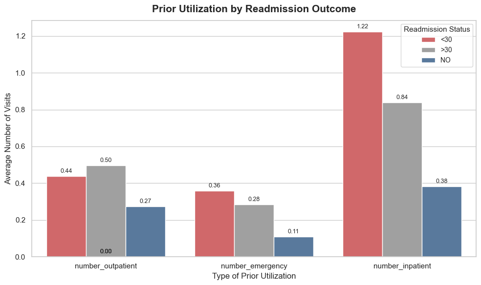

##### **Utilization & Severity Insights:**

**Length of Stay**

**Prior Utilization**

- Highest <30-day hospital readmission average number of visits for `num_inpatients` with 1.22 average followed by `num_outpatients` with 0.44 average.

**Diagnoses and Comorbidity Features EDA Questions:**

*To assess diagnosis data and highlight the need for clinically meaningful abstraction*

- Which diagnosis codes are most frequent?
- Are certain diagnosis groups overrepresented among readmitted cases?
- Do chronic conditions cluster together?
- Does comorbidity count increase readmission risk?

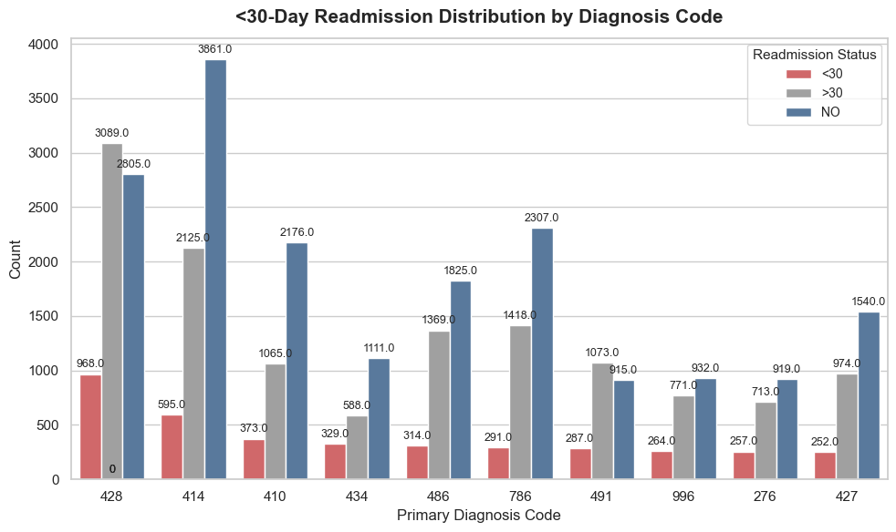

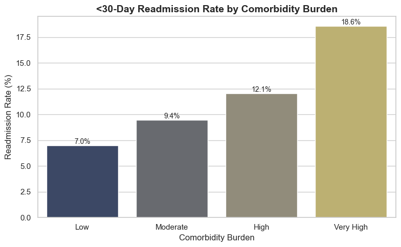

##### **Diagnosis and Comorbidity Insights:**

**Diagnosis Code**

**Chronic Condition Correlation**

**Comorbidity Burden**

#### **4. Feature Engineering**

*In alignment with CMS-style readmission metrics, this part transformed raw variables into representations that are domain-specific, meaningful, and usable by models*

Check and remove duplicates

Drop unnecessary columns

- `encounter_id`and `patient_nbr` columns are unique identifiers.
- Even if 23.45% of `patient_nbr` have multiple encounters, the corresponding multiple `encounter_id` per `patient_nbr` does not represent the sequence or duration in between readmission.
- `encounder_id` is also not a good data to do seasonality analysis since there is a possibility that `encounter_id` ordering is not chronological ordering.
- In terms of CMS-style readmission, they only evaluate the current encounter and outcome thus the said two columns may be dropped.

##### **Processing Age of Patients**

*Since the `age` column contains categorical age ranges (e.g., '[0-10)', '[10-20)'), these categories were mapped to their respective average values using a dictionary. After the mapping, the average age of patients were calculated in the dataset using the `.mean()` method.*

##### **Processing Length of Stay**

*The `time_in_hospital` column contains numerical feature from 1 to 14 days. Two additional features will be created where one feature is the binary "long stay" flag since EDA shows risk increase after 7 days. The other feature column is a simple categorical bin for easier SHAP interpretation.*

##### **Processing Payer Code**

*The `payer_code` column contains 18 different categories of insurance payer. These will be grouped into standard healthcare payer categories to ensure reproducibility and alignment with established health services.*

##### **Processing Diagnosis Code**

*`diag_1`, `diag_2`, and `diag_3` will be grouped into clinical categories to reduce dimensionality and prevent overfitting. Chronic disease indicators and comorbidity count will be created to capture disease burden that influences readmission risk.*

##### **Processing Admission and Discharge**

*`admission_type_desc`, `admission_source_desc`, and `discharge_disposition_desc` columns will be transformed into binary indicators capturing emergency, care transitions, and post-discharge dependency to reduce categorical noise.*

#### **5. Feature Selection**

*This part of the project used filter-based approach to identify features statistically associated with 30-day readmission while remaining model-agnostic, reducing overfitting and improving interpretability.*

##### **Chi-square test** for filtering categorical columns

*Since the dataset is high-dimensional and dominated by categorical features, chi-square filter approach is used because it can efficiently evaluates the statistical association between each categorical feature and readmission outcoome independently.*

### **Step 4: Model Implementation**

In this part of the project, the following will be conducted:

1. Three models will be implemented to train the model
   - **Regularized Logistic Regression** as baseline model to benchmark more complex machine learning approach
   - **Random Forest** for the nonlinear features relationships and robust to outliers
   - **GradientBoost** as the final model due to its strong performance to model complex nonlinear interactions associated with readmission risk.
2. CMS-style evaluation metric

##### **Scaling** of numerical features

*This numerical feature scaling is conducted inside the pipeline to prevent data leakage to the test set.* *RobustScaler** is chosen because it can mitigate the effect of extreme outliers from the utilization features.*

##### **One-hot encoding** of categorical features

*This encoding is conducted inside the pipeline since to prevent data leakage to the test set and to keep the encoded categoricals untouched by scaling.*

> *"Unknown category encountered during transformation were encoded as all zeros to prevent data leakage and ensure model robustness. While this may reduce information for rare categories, it aligns with best practices for healthcare predictive modeling and maintains deployment stability"*

##### Multicollinearity Checking

*This part of the project identidies redundant predictors that could compromise interpretability and generalization*

|  | Feature1 | Feature2 | corr |
| --- | --- | --- | --- |
| 860 | long_stay_flag | los_group_ord | 0.763290 |
| 2211 | discharged_home | discharged_to_facility | 0.718852 |

```
Dropped features due to multicollinearity:
['los_group_ord', 'discharged_to_facility']
```

##### Dimensionality Reduction

*This part of the project reduced high-dimensional data from diagnosis codes, medical-specialty, and admission & discharged patterns that resulted to thousands of features.*

```
Explained Variance Ratio (2 components): [0.15862313 0.12285977]
Cumulative Variance: [0.15862313 0.28148291]
```

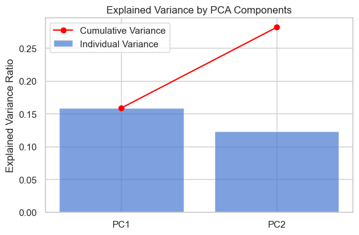

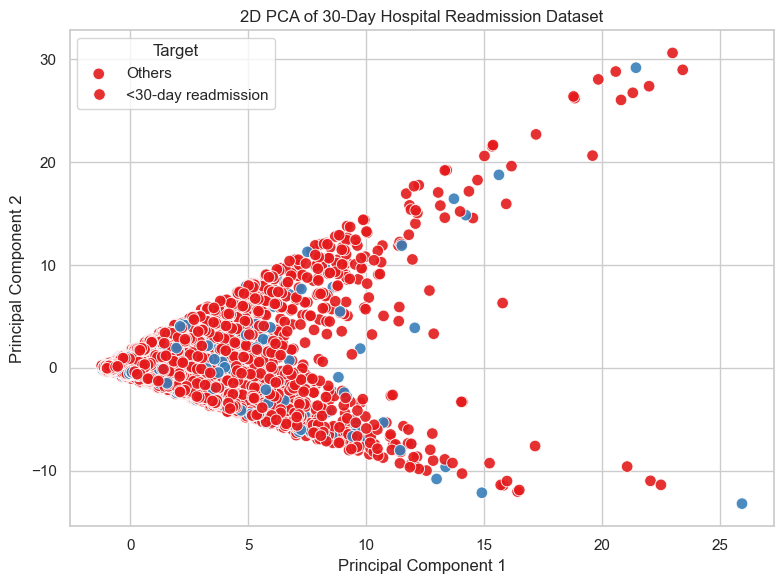

##### Train model

```
Best model saved: GradientBoosting (AUC-ROC = 0.6736)
```

|  | Model | Recall @ P≥0.80 |
| --- | --- | --- |
| 1 | RandomForest | 0.00044 |
| 2 | GradientBoosting | 0.00044 |
| 0 | LogisticRegression | 0.00000 |

Recall @ fixed precision (important for imbalanced medical datasets)

```
LogisticRegression - Recall @ Precision ≥ 0.8: 0.000
RandomForest - Recall @ Precision ≥ 0.8: 0.000
GradientBoosting - Recall @ Precision ≥ 0.8: 0.000
```

### **Step 5: Critical Thinking → Ethical AI & Bias Auditing**

##### **Model Explainability**

**SHAP tool** is used to explain each feature contribution value to push a specific patient's risk relative to the baseline readmission rate.

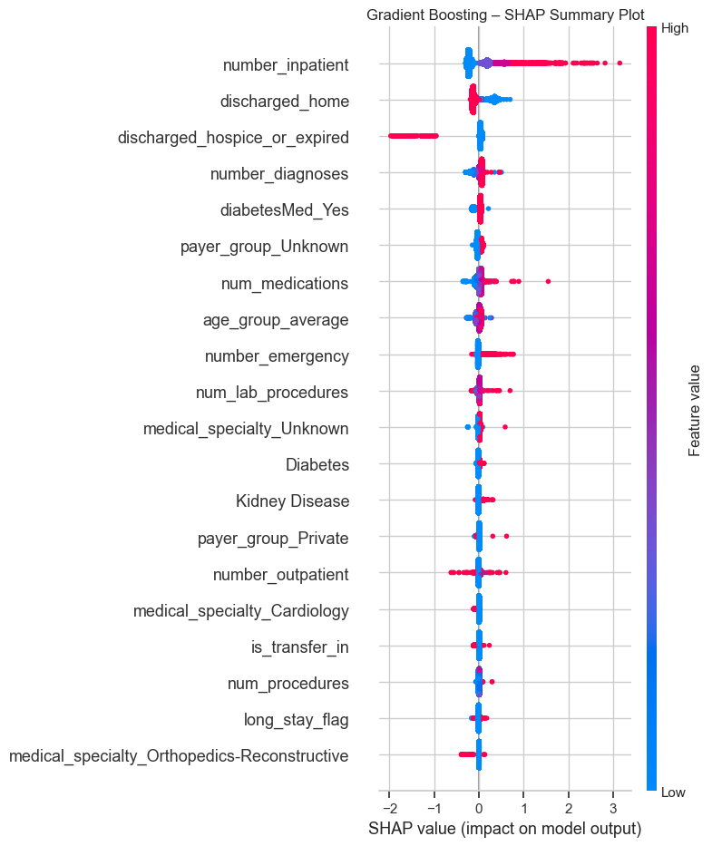

**SHAP Summary Plot Interpretation:**

- The strongest driver for readmission is `num_inpatient` with high feature value on the right side of baseline means *high inpatient visit = increase risk*
- But since it also has a *wide spread*, this feature *still varies for each patient*.
- Other features that have **positive wide SHAP** spread are:
  - `num_medications`
  - `num_emergency`
  - `num_procedures`
- The features with **negative SHAP** that reduces the probability of readmission:
  - `discharge_home`
  - `discharge_hospice_or_expired`
  - `medical_specialty_Orthopedics-Reconstructive`
  - if the patient has the following feature value above, their readmission risk goes down
- The `num_outpatient` feature both have almost equal **high feature values on the positive and negative side of the baseline** which means that high outpatient visit count sometimes increase risl or decrease risk depending on patient context.

**Fairness Metric Interpretation per attributes:**

**Disparate Impact Interpretation per attributes:**

**Overall Disparate Impact Interpretation:**

##### **Document Limitations**

1. Class imbalance
   - class imbalance was addressed by using `class_weight` for Logistic Regression and Random Forest. This is the primary strategy because I want to **keep the clinical realism of the data** instead of creating unrealistic synthetic samples.
   - **No threshold tuning** for GradientBoost was conducted to mitigate class imbalance becuase I used a code that will iterate to the 3 models chosen above.
   - But since all the True Positive Rates are all <0.60, `SMOTE` will be the **second strategy** for recall improvement.
2. Feature Limitations
   - The raw columns of my feature engineered data were dropped for the purpose of reduced redundacy and dimensionality reduction.
   - This is not a standard practice but training the model with thousands of features takes too much time to train and tune and retrain again.
   - I hypothesized that if I created feature engineered columns based on CMS domain-specific, it will have better perfomance compared to other existing hospital readmission models, but it seems to be not the case.
   - This strategy is largely affected by **class imbalance**.
3. Data Leakage
   - I went back and forth if I should put *scaling and encoding before model implementation* (as the capstone_guide and previous lessons suggested) or *putting after splitting the train and test set based on what I read on ResearchGate* *to prevent data leakage***.
   - It is possible that the performance metric result is caused by this. Either it will overfit or underfit, reinforcing the complexity of the problem.

##### **Future Work**

1. Learn to minimize runtime while processing high-dimensional data.
2. Improve skills on how to handle class imbalance.
3. Improve skills on parameter tuning.